# DLL-ES IRT Analysis and Recommendations

George Kachergis

2023-10-15

## Goals

The goals are 1) to create a word list that is informative about both English and Spanish vocabulary size and 2) to ensure that there are sufficient doublets to estimate lexical overlap. On an IRT view, we can’t perfectly assess 2 (at least not without better bilingual CDI data), but we can assess criterion 1 - that is, we can look at whether the reduced word list is a good sub-test for the full CDI in each language. Our original concern was that the current DLL-ES test might not perform well for older or high ability kids due to the lack of abstract words, and we can test this formally.

The DLL lists are meant to be used together with the original English and Spanish MCDI short forms.

Now we need to match the DLL words to the wordbank items for which we have IRT parameters.

### Matching DLL short Level 1

```r
# use with EN WG short form (12-18 mos)
#dll1ENshort <- read_csv(here("DLL/DLL-ES1-short-English.csv")) # 79 items (81 after splitting defs)

dll1short <- dll1short_raw %>% # this is now 168 items...it has the WG short form included
  mutate(english = tolower(english)) %>%
  mutate(english = case_when(english == 'i' ~ 'I',
                          english == 'tv (television)' ~ 'TV',
                          english == 'water' ~ 'water (beverage)',
                          english == 'grandma (or word used in your family)' ~ 'grandma*',
                          english == 'mommy (or word used in your family)' ~ 'mommy*',
                          english == 'choo choo (train sound)' ~ 'choo choo',
                          english == 'patty cake' ~ 'pattycake',
                          english == 'bye or bye bye' ~ 'bye',
                          english == 'teddy bear' ~ 'teddybear',
                          english == 'his/her' ~ 'his', # hers ? (and should DLL say 'his/hers' ?)
                          english == 'to have' ~ 'have',
                          english == 'shh' ~ 'shh/shush/hush',
                          english == 'to sit' ~ 'sit',
                          english == 'to be' ~ 'be',
                          english == 'put, put on' ~ 'put',
                          english == 'to write' ~ 'write',
                          english == 'arms' ~ 'arm',
                          english == 'church (or word used in your family)' ~ 'church*',
                          english == 'want' ~ 'wanna/want to',
                          english == 'in' ~ 'inside/in', # into ?
                          TRUE ~ english))

dll1ENshort_num_matching = length(intersect(dll1short$english, coefs$en$definition))
# 75/81 (GK version)
# 160/168 (Sandy)
#setdiff(dll1short$english, coefs$en$definition)

# are these items also on the short form CDIs?
#length(intersect(dll1short$english, wg_short_en$word)) # all of the WG
#length(intersect(dll1short$english, ws_short_enA$word)) # 36 of the WS
```

```r
# use with SP WG short form (12-18 mos)
#dll1SPshort <- read_csv(here("DLL/DLL-ES1-short-Spanish.csv")) # 67 items

dll1short <- dll1short %>% # this is now 168 items...it has the WG short form included
  mutate(spanish = tolower(spanish)) %>%
  separate(col = spanish, into = c("spanish", NA), sep=" \\(") %>%
  mutate(spanish = case_when(spanish == 'mamá/mami' ~ 'mamá',
                             spanish == 'calcetines' ~ 'calcetín',
                             spanish == 'tomar baño / bañarse' ~ 'baño', # verb -> noun.. tomar(se) ?
                             spanish == 'espera' ~ 'esperar(se)', # close enough ?
                             spanish == 'acabar(se)' ~ 'acabar',
                             spanish == 'no hay más' ~ 'no hay', # or "más" ?
                             spanish == 'rapido' ~ 'rápido (descriptive)', # or rápido (quantifiers)
                             spanish == 'lastimado' ~ 'lastimar(se)', # close enough ?
                             spanish == 'otro' ~ 'otro/otra vez', # close enough ?
                             spanish == 'quiquiriqui' ~ 'quiquiriquí', # DLL missing acent
                             spanish == 'brazos' ~ 'brazo',
                             spanish == 'manos' ~ 'mano',
                             spanish == 'vaso' ~ 'vasos',
                             spanish == 'llaves' ~ 'llave',
                             spanish == 'adiós/byebye' ~ 'adíos/byebye', # wordbank accent is incorrect
                             spanish == 'uno, dos, tres' ~ 'uno dos tres...',
                             spanish == 'shh' ~ 'shhh',
                             spanish == 'ver' ~ 'ver(se)',
                             spanish == '¿dónde está?' ~ 'dónde', # close enough ?
                             TRUE ~ spanish))

dll1SPshort_num_matching = length(intersect(dll1short$spanish, coefs$sp$definition)) # was 59 on GK version
# 158 / 168
#setdiff(dll1short$spanish, coefs$sp$definition)
# no match: tostada, alimentar, sonreír, algunos, también

# are these items also on the short form CDIs?
#length(intersect(dll1short$spanish, wg_short_sp$word)) # all of the WG
#length(intersect(dll1short$spanish, ws_short_sp$word)) # 63 of the WS
```

### Matching DLL short Level 2

```
## [1] 153
```

### Matching DLL Extended Level 1

```r
dll1long <- dll1long_raw %>% mutate(english = tolower(english)) %>%
  mutate(english = case_when(english == 'daddy (or word used in your family)' ~ 'daddy*',
                          english == 'toy' ~ 'toy (object)',
                          english == 'swing' ~ 'swing (object)', # or swing (action) ?
                          english == 'dress' ~ 'dress (object)',
                          TRUE ~ english))


dll1long_EN_num_matching = length(intersect(dll1long$english, coefs$en$definition)) # 74 / 74 match

dll1long <- dll1long %>% mutate(spanish = tolower(spanish)) %>%
  separate(col = spanish, into = c("spanish", NA), sep=" \\(") %>%
  mutate(spanish = case_when(spanish == 'pipi' ~ 'pipí', # is this a match?
                             spanish == 'orejas' ~ 'oreja',
                             spanish == 'dedos' ~ 'dedo',
                             spanish == 'escalera' ~ 'escaleras',
                             spanish == 'bolsa' ~ 'bolsa (clothing)', # or bolsa (household) ?
                             spanish == 'papá/papi' ~ 'papá',
                             spanish == 'cosquillita' ~ 'cosquillitas',
                             spanish == 'hacer la meme' ~ 'siesta', # close enough ?  or hacer?
                             TRUE ~ spanish))

dll1long_SP_num_matching = length(intersect(dll1long$spanish, coefs$sp$definition)) # 74 / 74 match
```

### Matching DLL Extended Level 2

```r
dll2long <- dll2long_raw %>% mutate(english = tolower(english)) %>%
  mutate(english = case_when(english == 'daddy (or name/word used in your family)' ~ 'daddy*',
                          english == 'teddy bear' ~ 'teddybear',
                          english == 'patty cake' ~ 'pattycake', # or swing (action) ?
                          english == 'dress' ~ 'dress (object)',
                          english == 'i' ~ 'I',
                          english == 'penis (or word used in your family)' ~ 'penis*',
                          english == 'water' ~ 'water (beverage)',
                          english == 'orange' ~ 'orange (food)',
                          english == 'clock/watch' ~ 'clock', # or watch (object)
                          english == 'drink' ~ 'drink (action)',
                          english == 'feet' ~ 'foot',
                          english == 'picture (\"or photo\")' ~ 'picture',
                          english == 'buttocks/bottom (or word used in your family)' ~ 'buttocks/bottom*',
                          TRUE ~ english))

dll2long <- dll2long %>% mutate(spanish = tolower(spanish)) %>%
  separate(col = spanish, into = c("spanish", NA), sep=" \\(") %>%
  mutate(spanish = case_when(spanish == 'pipi' ~ 'pipí',
                          spanish == 'shh' ~ 'shhh',
                          spanish == 'bolsa' ~ 'bolsa (clothing)', # or bolsa (household) ?
                          spanish == 'qué' ~ 'qué (question_words)',
                          TRUE ~ spanish))

#length(intersect(dll2long$spanish, coefs$sp$definition))
#setdiff(dll2long$spanish, coefs$sp$definition)
```

English DLL items not in our wordbank IRT model: *one, two, three*, *family*, *drum*, *good morning*, *also*, and *many*. Spanish DLL items not in our wordbank IRT model: *tostada*, *algunos*, *alimentar*, *sonreír*, *no hay más* (although we have *no* and *no hay*, as well as *más*), and lastimado (but we have *lastimar(se)*).

## Does the DLL short form recover full form scores?

### English DLL Level 1: Production

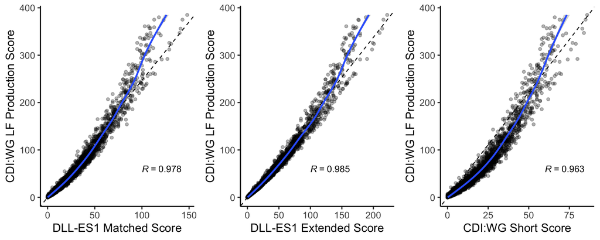

### English DLL Level 1: Comprehension

Now we do the same for comprehension (receptive vocabulary) using Wordbank’s CDI:WG English data.

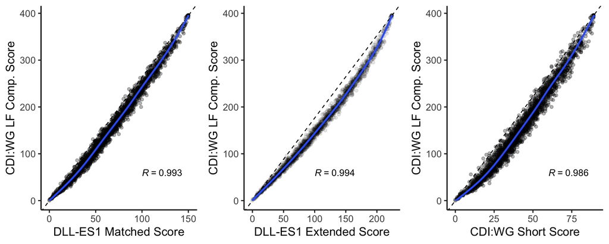

The correlation of children’s DLL1 scores and their CDI:WG LF comprehension scores is quite high ($r=0.99$), and extrapolating from the DLL-ES1 to full CDI:WG scores shows very little overestimation (less than when using the CDI:WG short form alone).

### English DLL Level 2 (Production)

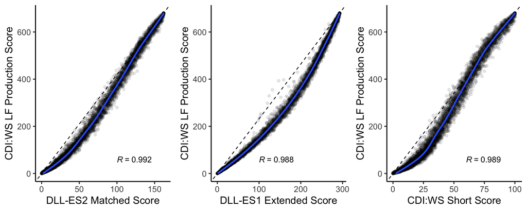

Overall, the correlation of children’s CDI:WS short + DLL2 scores and their full CDI production scores is quite high ($r=0.99$), but as shown above, the DLL2 again mostly overestimates production scores on the full CDI (dotted line has slope $=162 / 680$). In comparison, the CDI:WS short form (A) score only overestimates full CDI scores for smaller vocabulary sizes (<400).

### Spanish DLL Level 1

Now we look at overestimation for Spanish DLLs + CDI short forms.

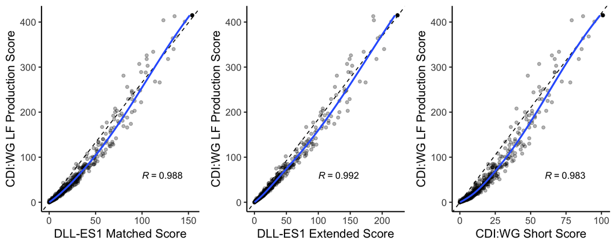

Using Wordbank data from 731 Spanish-speaking children aged 12-18 months, we test how well sumscores from the DLL-ES1 Matched form correlate with children’s full CDI:WG production scores.

As for English, the correlation of Spanish-speaking children’s DLL scores and their full CDI:WG production scores is quite high ($r=0.99$), but as shown above, their DLL score overestimates the production score on the full CDI at smaller vocabulary sizes (dotted line has slope $=161 / 428$). Do note that few children in this dataset have large productive vocabularies.

### Spanish DLL Level 1: Comprehension

Now we do the same for comprehension (receptive vocabulary) using Wordbank’s CDI:WG Spanish data.

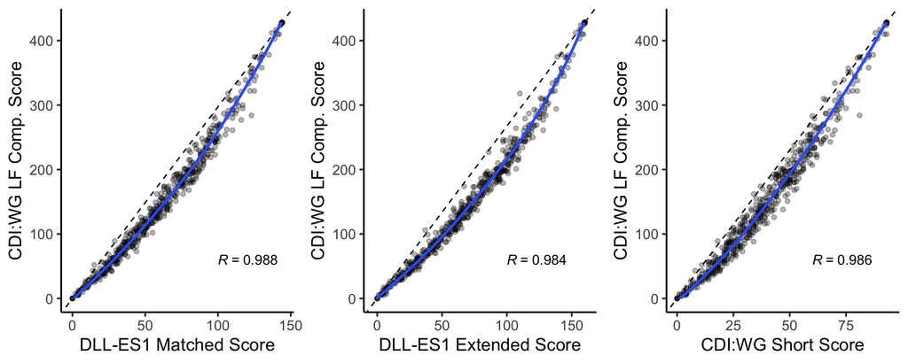

The correlation of children’s DLL1 Matched scores and their full CDI:WG comprehension scores is quite high ($r=0.99$), and extrapolating from DLL to full CDI:WG scores shows very little overestimation–similar to the level shown by using the CDI:WG alone.

### Spanish DLL Level 2 (Production)

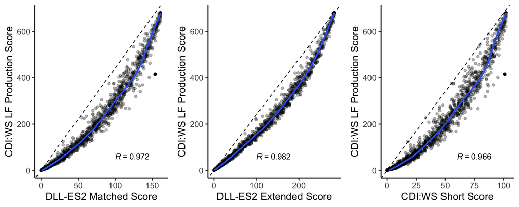

## Full CDI vs. Short CDI / DLL Correlations

[output not shown]

## Recommendations

Overall, it seems that many of the items on the DLL are somewhat easier than average, and thus these forms tend to overestimate children’s full CDI scores (indeed, for English items on the DLL1 Matched form, the average easiness is -0.95, while the mean easiness of items not on the DLL is -2.57). This is also true of the CDI:WG short English form: the average easiness is -0.64 and the average ease of items not on the WG short form is -2.42. The CDI:WS short English form (A) is less biased towards easy items: average easiness is -1.73 vs. -2.27 for items not on the short WS. The histograms below show the distribution of easiness parameters for English (left) and Spanish (right) CDI words. Solid lines show the average ease of DLL items (DLL 1 = red, DLL 2 = orange), and dashed lines show the average of non-DLL items.

Spanish DLL1 items have an average ease of -0.81, while other items on the full CDI have a mean ease of -2.27.

English DLL2 items have an average ease of -1.67, while other items on the full CDI have a mean ease of -2.35.

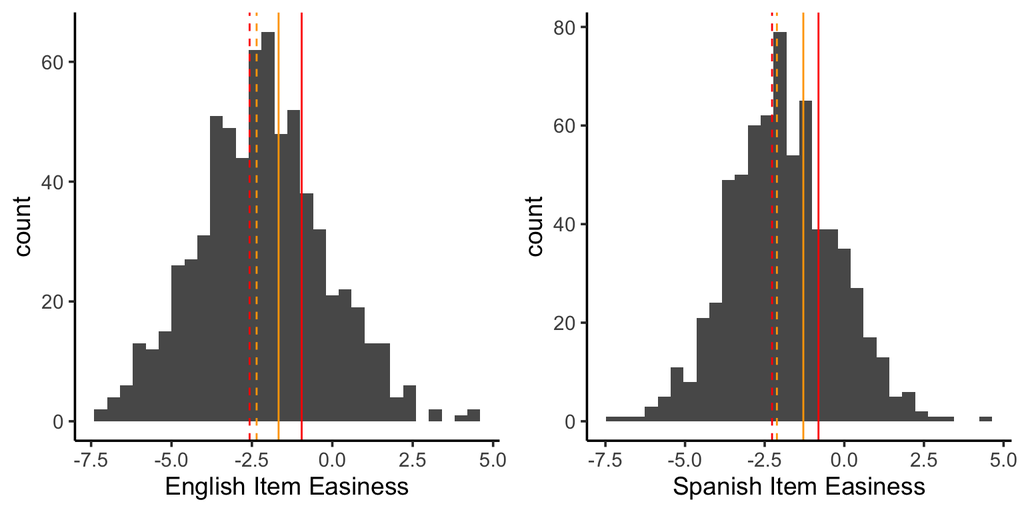

We recommend bringing the overall mean estimated IRT difficulty of the words selected for the DLLs closer to the mean difficulty of the words on the rest of the CDI.

To start, we examine IRT easiness parameters for the doublets on the existing DLL lists, looking for items with large mismatch between their English and Spanish ease.

## Do doublets have similar difficulties?

We want to whether assess doublet items have similar difficulty (operationalized by their IRT parameters) in English and in Spanish. For example, consider if “perro” was for some reason much more difficult than “dog”, then you wouldn’t want to include it because it wouldn’t be a good item for estimating vocabulary overlap!

Below are shown the parameters for items from the DLL-ES1 Matched form: en_d = English easiness, sp_d = Spanish easiness), ordered by the most to least discrepant (difficulty difference squared); (_a1 columns show item discriminations (slopes), and en_sp_d_diff simply shows the difference (English - Spanish) in the easiness parameter).

### DLL Level 1 Short Form

For the Matched form, we merely want to identify items that have very different difficulty in English and Spanish, and recommend that researchers interested in estimating conceptual overlap in bilinguals not include these items in their calculations due to the bias. Below is shown the distribution of the squared difference in difficulty for doublets from the DLL Level 1 short form.

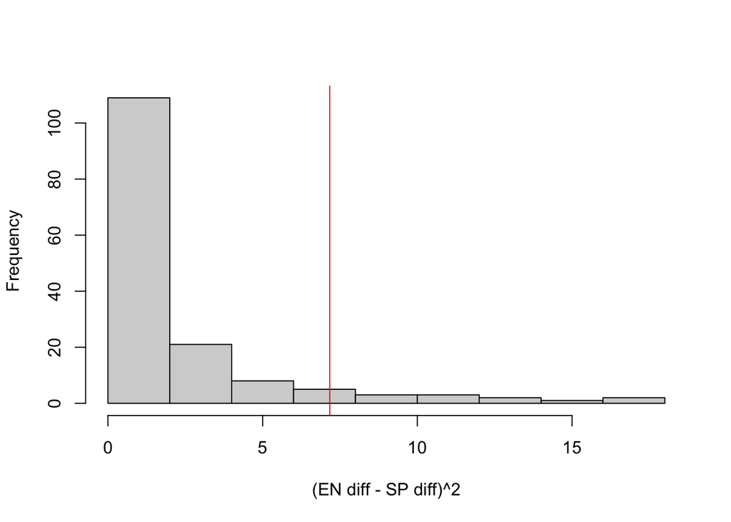

The mean squared difference in difficulty of doublets on the DLL-ES1 Matched form is 2.16 (SD=3.33), and as shown above this distribution is highly skewed: most doublets are fairly well-matched (median d_diff_sq=0.99), but a few items are extremely mismatched. We recommend that the 13 items (shown below) with a squared difficulty difference of 7.17 (mean + 1.5 * SD) or more be excluded from calculations of conceptual overlap.

| english | spanish | sp_a1 | sp_d | en_a1 | en_d | en_sp_d_diff | d_diff_sq |
| --- | --- | --- | --- | --- | --- | --- | --- |
| street | calle | 3.24 | 0.78 | 4.39 | -3.38 | -4.16 | 17.35 |
| book | libro | 3.80 | -1.55 | 2.88 | 2.55 | 4.10 | 16.83 |
| on | encima | 2.96 | -4.38 | 2.93 | -0.45 | 3.93 | 15.46 |
| none | no hay | 2.71 | -0.29 | 2.37 | -3.85 | -3.55 | 12.63 |
| hat | sombrero | 3.28 | -2.14 | 3.15 | 1.37 | 3.51 | 12.33 |
| don’t | no | 1.50 | 1.81 | 1.95 | -1.61 | -3.42 | 11.70 |
| water (beverage) | agua | 2.58 | 4.38 | 2.80 | 0.99 | -3.38 | 11.46 |
| other | otro/otra vez | 2.34 | -0.84 | 3.09 | -4.05 | -3.22 | 10.34 |
| dish | plato | 4.57 | 0.17 | 2.99 | -2.90 | -3.06 | 9.39 |
| babysitter | nana | 0.97 | -1.36 | 2.41 | -4.31 | -2.94 | 8.67 |
| bread | pan | 2.59 | 2.50 | 3.33 | -0.35 | -2.85 | 8.10 |
| finish | acabar | 2.51 | -0.93 | 3.13 | -3.68 | -2.75 | 7.55 |
| today | hoy | 2.04 | -2.29 | 3.79 | -5.01 | -2.72 | 7.40 |

### DLL Level 2 Matched Form

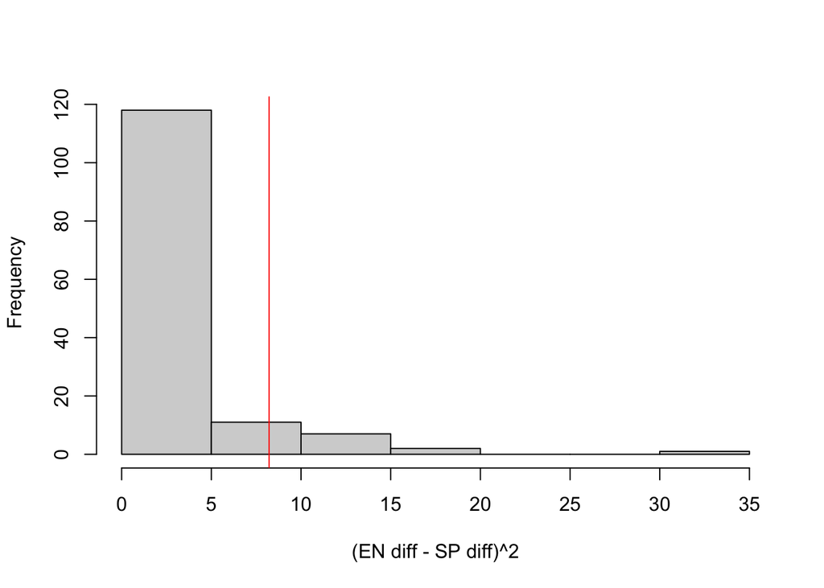

| english | spanish | sp_a1 | sp_d | en_a1 | en_d | en_sp_d_diff | d_diff_sq |
| --- | --- | --- | --- | --- | --- | --- | --- |
| if | que (connection word) | 1.50 | -0.82 | 3.12 | -6.53 | -5.71 | 32.63 |
| street | calle | 3.24 | 0.78 | 4.39 | -3.38 | -4.16 | 17.35 |
| book | libro | 3.80 | -1.55 | 2.88 | 2.55 | 4.10 | 16.83 |
| to | a | 1.00 | -0.15 | 3.43 | -3.80 | -3.65 | 13.32 |
| none | no hay | 2.71 | -0.29 | 2.37 | -3.85 | -3.55 | 12.63 |
| hat | sombrero | 3.28 | -2.14 | 3.15 | 1.37 | 3.51 | 12.33 |
| hear | oír | 1.83 | -0.94 | 4.49 | -4.35 | -3.41 | 11.61 |
| bench | banco (outside) | 2.94 | -2.18 | 3.59 | -5.43 | -3.25 | 10.57 |
| much | mucho | 3.33 | -1.80 | 3.10 | -5.04 | -3.24 | 10.48 |
| potato | papas | 2.54 | 1.11 | 2.90 | -2.07 | -3.18 | 10.12 |

Now we examine the doublets on the long supplemental DLL forms, and make recommendations of mismatched items to swap out.

### DLL Level 1 Extended

Below are shown the parameters for items from the DLL Level 1 extended form. Clearly some of these items have quite different difficulty levels in English and Spanish, and we should try to find items that are more equivalent and swap them onto the long supplement.

| english | spanish | sp_a1 | sp_d | en_a1 | en_d | en_sp_d_diff | d_diff_sq |
| --- | --- | --- | --- | --- | --- | --- | --- |
| give | dar | 2.25 | -0.59 | 3.88 | -3.13 | -2.54 | 6.45 |
| ear | oreja | 4.68 | -0.46 | 3.68 | 1.69 | 2.16 | 4.65 |
| cheese | queso | 3.93 | -0.63 | 2.89 | 1.45 | 2.08 | 4.33 |
| crib | cuna | 2.92 | -0.51 | 3.09 | -2.42 | -1.90 | 3.62 |
| banana | plátano/banana | 2.95 | 0.01 | 2.26 | 1.89 | 1.88 | 3.54 |
| shirt | playera | 3.47 | -2.44 | 4.14 | -0.58 | 1.85 | 3.43 |
| chicken (food) | pollo | 3.94 | 0.72 | 3.46 | -1.01 | -1.73 | 2.99 |
| moo | muu | 1.22 | 0.01 | 1.87 | 1.70 | 1.69 | 2.85 |
| nap | siesta | 1.98 | -2.71 | 3.79 | -1.05 | 1.67 | 2.78 |
| apple | manzana | 3.76 | -0.07 | 3.22 | 1.55 | 1.62 | 2.62 |
| stop | parar(se) | 3.76 | -2.43 | 2.80 | -0.81 | 1.62 | 2.62 |
| drawer | cajón | 4.17 | -2.32 | 3.67 | -3.85 | -1.53 | 2.35 |
| face | cara | 4.25 | -0.36 | 3.92 | -1.83 | -1.48 | 2.18 |
| swing (object) | columpio | 3.80 | -1.96 | 3.21 | -0.49 | 1.47 | 2.16 |
| belly button | ombligo | 3.33 | -1.23 | 2.68 | 0.22 | 1.45 | 2.11 |
| quack quack | cuacuá | 1.26 | -0.28 | 1.80 | 1.10 | 1.38 | 1.89 |
| picture | fotos | 4.46 | -0.97 | 4.50 | -2.34 | -1.37 | 1.87 |
| go | ir(se) | 2.36 | -0.71 | 2.43 | 0.60 | 1.32 | 1.73 |
| bunny | conejo | 3.41 | -1.06 | 2.75 | 0.23 | 1.29 | 1.67 |
| trash | basura | 4.54 | -0.03 | 2.20 | -1.28 | -1.25 | 1.56 |
| pen | lápiz | 3.71 | -0.10 | 2.79 | -1.34 | -1.24 | 1.54 |
| bite | morder | 3.72 | -1.77 | 2.82 | -0.54 | 1.23 | 1.51 |
| comb | peine | 3.94 | -0.68 | 2.92 | -1.90 | -1.23 | 1.50 |
| baa baa | bee/mee | 0.83 | -0.30 | 1.17 | 0.90 | 1.20 | 1.45 |
| paper | papel | 4.18 | -0.02 | 4.19 | -1.22 | -1.19 | 1.43 |
| window | ventana | 4.28 | -1.11 | 3.45 | -2.29 | -1.18 | 1.39 |
| store | tienda/mercado | 3.66 | -0.95 | 4.33 | -2.06 | -1.10 | 1.22 |
| dance | bailar | 3.18 | -0.40 | 3.38 | -1.39 | -0.99 | 0.98 |
| tree | árbol | 3.78 | -0.53 | 3.18 | 0.45 | 0.98 | 0.96 |
| hit | pegar(se) | 3.48 | -1.39 | 3.89 | -2.35 | -0.97 | 0.93 |
| finger | dedo | 4.43 | 0.22 | 4.32 | -0.73 | -0.96 | 0.91 |
| purse | bolsa (clothing) | 3.93 | -0.83 | 2.72 | -1.75 | -0.93 | 0.86 |
| daddy* | papá | 1.48 | 2.96 | 1.70 | 3.87 | 0.91 | 0.84 |
| bear | oso | 2.96 | -0.09 | 2.48 | 0.81 | 0.91 | 0.83 |
| touch | tocar | 3.18 | -2.17 | 3.75 | -3.03 | -0.86 | 0.73 |
| door | puerta | 4.68 | -0.28 | 3.37 | 0.52 | 0.80 | 0.64 |
| clock | reloj | 3.80 | -1.51 | 2.40 | -0.73 | 0.78 | 0.61 |
| tongue | lengua | 3.87 | -0.50 | 3.16 | -1.27 | -0.78 | 0.60 |
| open | abrir | 3.41 | 0.22 | 3.57 | -0.55 | -0.78 | 0.60 |
| balloon | globo/bomba | 2.35 | 1.12 | 2.56 | 1.78 | 0.65 | 0.43 |
| medicine | medicina | 4.31 | -1.38 | 3.55 | -1.98 | -0.60 | 0.35 |
| cry | llorar | 3.81 | -1.08 | 4.08 | -1.67 | -0.59 | 0.35 |
| bathtub | tina | 3.07 | -1.03 | 2.79 | -0.45 | 0.58 | 0.33 |
| vroom | pipí | 1.76 | 1.19 | 0.93 | 0.61 | -0.58 | 0.33 |
| box | caja | 4.25 | -1.28 | 3.30 | -0.71 | 0.57 | 0.33 |
| pajamas | pijama | 3.51 | -2.06 | 3.82 | -1.50 | 0.57 | 0.32 |
| foot | pies | 3.78 | 0.65 | 3.86 | 0.10 | -0.55 | 0.30 |
| bicycle | bicicleta | 2.93 | -0.90 | 3.02 | -0.36 | 0.54 | 0.29 |
| towel | toalla | 4.89 | -2.02 | 4.12 | -1.51 | 0.52 | 0.27 |
| refrigerator | refrigerador | 3.96 | -2.52 | 3.75 | -3.02 | -0.50 | 0.25 |
| dress (object) | vestido | 3.29 | -1.69 | 2.96 | -2.17 | -0.48 | 0.23 |
| button | botón | 2.97 | -0.96 | 2.69 | -0.49 | 0.47 | 0.22 |
| cake | pastel | 3.64 | -0.35 | 3.53 | -0.72 | -0.37 | 0.13 |
| throw | tirar | 3.82 | -2.11 | 4.16 | -2.46 | -0.34 | 0.12 |
| horse | caballo | 2.99 | 0.65 | 3.34 | 0.32 | -0.34 | 0.11 |
| stairs | escaleras | 4.20 | -1.84 | 3.28 | -2.12 | -0.28 | 0.08 |
| wash | lavar(se) | 4.22 | -1.68 | 4.15 | -1.96 | -0.28 | 0.08 |
| man | señor | 3.96 | -1.76 | 2.79 | -2.04 | -0.27 | 0.07 |
| glasses | lentes | 3.93 | -1.45 | 3.20 | -1.20 | 0.25 | 0.06 |
| bib | babero | 3.01 | -1.16 | 2.19 | -0.92 | 0.24 | 0.06 |
| close | cerrar | 4.06 | -1.68 | 3.38 | -1.92 | -0.24 | 0.06 |
| airplane | avión | 2.81 | 0.24 | 2.97 | 0.48 | 0.24 | 0.06 |
| say | decir | 3.84 | -3.28 | 3.46 | -3.50 | -0.22 | 0.05 |
| telephone | teléfono | 3.18 | -0.25 | 3.47 | -0.04 | 0.21 | 0.04 |
| brush | cepillo | 4.80 | -0.24 | 3.13 | -0.44 | -0.20 | 0.04 |
| thank you | gracias | 2.27 | 1.35 | 2.04 | 1.17 | -0.18 | 0.03 |
| pillow | almohada | 3.89 | -1.14 | 4.09 | -0.96 | 0.18 | 0.03 |
| light | luz | 3.38 | 0.50 | 2.72 | 0.38 | -0.12 | 0.01 |
| diaper | pañal | 3.79 | 1.00 | 3.00 | 0.89 | -0.10 | 0.01 |
| hair | pelo | 5.15 | 0.85 | 4.09 | 0.95 | 0.10 | 0.01 |
| toy (object) | juguete | 3.58 | -0.39 | 3.57 | -0.33 | 0.07 | 0.00 |
| tickle | cosquillitas | 2.06 | -0.92 | 2.47 | -0.87 | 0.05 | 0.00 |
| walk | caminar | 3.26 | -1.10 | 3.59 | -1.07 | 0.03 | 0.00 |
| blow | soplar | 2.67 | -1.58 | 3.18 | -1.59 | -0.01 | 0.00 |

### DLL Level 2 Extended

| english | spanish | sp_a1 | sp_d | en_a1 | en_d | en_sp_d_diff | d_diff_sq |
| --- | --- | --- | --- | --- | --- | --- | --- |
| bubbles | burbujas | 3.02 | -2.63 | 2.61 | 1.30 | 3.94 | 15.50 |
| water (beverage) | agua | 2.58 | 4.38 | 2.80 | 0.99 | -3.38 | 11.46 |
| soup | sopa | 2.41 | 1.36 | 2.98 | -1.98 | -3.34 | 11.15 |
| bread | pan | 2.59 | 2.50 | 3.33 | -0.35 | -2.85 | 8.10 |
| table | mesa | 4.61 | 0.34 | 5.01 | -2.22 | -2.56 | 6.55 |
| coat | abrigo | 2.63 | -3.09 | 2.70 | -0.80 | 2.29 | 5.22 |
| pencil | lápiz | 3.71 | -0.10 | 3.23 | -2.31 | -2.21 | 4.90 |
| bee | abeja | 2.62 | -2.19 | 2.53 | -0.08 | 2.10 | 4.43 |
| chocolate | chocolate | 3.35 | -0.04 | 3.11 | -2.12 | -2.09 | 4.35 |
| cheese | queso | 3.93 | -0.63 | 2.89 | 1.45 | 2.08 | 4.33 |
| crib | cuna | 2.92 | -0.51 | 3.09 | -2.42 | -1.90 | 3.62 |
| motorcycle | moto | 2.75 | -0.24 | 2.85 | -2.12 | -1.89 | 3.56 |
| girl | niña | 2.35 | 0.45 | 2.79 | -1.40 | -1.85 | 3.42 |
| soda/pop | soda/refresco | 2.13 | 0.31 | 1.59 | -1.51 | -1.82 | 3.31 |
| chicken (food) | pollo | 3.94 | 0.72 | 3.46 | -1.01 | -1.73 | 2.99 |
| nose | nariz | 4.20 | 0.45 | 3.42 | 2.18 | 1.73 | 2.99 |
| drink (action) | tomar(se) | 2.87 | -1.83 | 3.05 | -0.15 | 1.68 | 2.82 |
| cup | taza | 3.53 | -0.84 | 3.39 | 0.83 | 1.67 | 2.79 |
| knee | rodilla | 4.52 | -2.51 | 3.06 | -0.85 | 1.65 | 2.74 |
| apple | manzana | 3.76 | -0.07 | 3.22 | 1.55 | 1.62 | 2.62 |
| sing | cantar | 3.07 | -0.79 | 4.05 | -2.37 | -1.58 | 2.51 |
| bug | bicho | 1.58 | -1.80 | 2.74 | -0.22 | 1.58 | 2.50 |
| house | casa | 4.22 | 0.55 | 3.31 | -1.03 | -1.58 | 2.49 |
| blanket | cobija | 4.49 | -1.29 | 3.26 | 0.29 | 1.57 | 2.48 |
| face | cara | 4.25 | -0.36 | 3.92 | -1.83 | -1.48 | 2.18 |
| belly button | ombligo | 3.33 | -1.23 | 2.68 | 0.22 | 1.45 | 2.11 |
| stick | palo | 3.25 | -0.50 | 3.30 | -1.90 | -1.40 | 1.96 |
| quack quack | cuacuá | 1.26 | -0.28 | 1.80 | 1.10 | 1.38 | 1.89 |
| picture | fotos | 4.46 | -0.97 | 4.50 | -2.34 | -1.37 | 1.87 |
| I | yo | 2.25 | 0.23 | 2.11 | -1.11 | -1.34 | 1.79 |

[output cut: 101 more lines]

## Recommended Item Swaps

We will use Wordbank’s unilemmas to find translation-equivalent pairs that have smaller d_diff_sq values than current DLL extended items. We first get the English / Spanish unilemmas from wordbank (both WS and WG), and below simply show the Spanish vs. English easiness parameters.

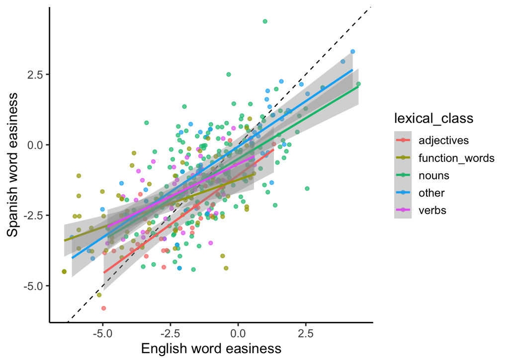

Below are shown the 101 unilemmas for which we have English and Spanish IRT parameters and that are *not* already on any of the DLL-ES lists (Level 1 or Level 2, short or supplemental lists). Items with small difficulty mismatch (d_diff_sq) can be chosen from this list to replace items with worse than average items on the DLL-ES supplemental forms. The median d_diff_sq on the DLL-ES Level 1 supplement is 0.602 (sd=1.351). The median d_diff_sq on the DLL-ES Level 2 supplement is 0.55 (sd=1.953).

Finally, for the hand-picked swaps we will report the original DLL list’s easiness SSE, as well as the improvement (in easiness SSE) after the final swaps are made.

|  | english | category | lexical_class | uni_lemma | spanish | en_d | sp_d | en_sp_d_diff | d_diff_sq |
| --- | --- | --- | --- | --- | --- | --- | --- | --- | --- |
| 1 | animal | animals | nouns | animal | animal | -1.747559784413548 | -1.387769651581296 | -0.3597901328322513 | 0.129448939683449 |
| 2 | deer | animals | nouns | deer | venado | -1.916720851052073 | -3.508220912160712 | 1.591500061108638 | 2.532872444508799 |
| 3 | donkey | animals | nouns | donkey | burro | -2.522157023095557 | -0.7966413218566738 | -1.725515701238883 | 2.977404435221914 |
| 4 | elephant | animals | nouns | elephant | elefante | -1.027062791667354 | -1.374909820713081 | 0.3478470290457265 | 0.1209975556159385 |
| 5 | fish (animal) | animals | nouns | fish (animal) | pescado | 1.095352282717046 | -1.680275881255638 | 2.775628163972684 | 7.704111704638371 |
| 6 | giraffe | animals | nouns | giraffe | jirafa | -1.507138264820882 | -2.850234525556014 | 1.343096260735132 | 1.803907565600694 |
| 7 | lamb | animals | nouns | lamb | borrego | -2.490181629977941 | -1.82517571484789 | -0.6650059151300503 | 0.4422328671579556 |
| 8 | owl | animals | nouns | owl | búho | -0.9873401891767722 | -2.255054609073967 | 1.267714419897195 | 1.60709985041528 |
| 9 | penguin | animals | nouns | penguin | pingüino | -2.59579564002407 | -3.776932382953236 | 1.181136742929166 | 1.395084005497319 |
| 10 | pig | animals | nouns | pig | puerco | 0.09814670209884085 | -1.844265260878004 | 1.942411962976845 | 3.772964233915559 |

[output cut: 91 more lines]

## DLL-ES1 Extended Form Swaps

The average discrepancy on the original DLL-ES1 Extended was 1.12, with the Spanish items being on average more difficult than their English equivalents (English - Spanish ease: 0.09). After substituting 15 of the items with the largest discrepancy, the average discrepancy was 0.6, and the overall difference between languages was closer to zero (English - Spanish ease: 0.01).

Now we evaluate the swaps for the DLL-ES2 Extended form.

## New DLL vs. Full CDI Correlations

Finally, we re-evaluate the correlations between full CDI scores and DLL scores after the above swaps on the DLL-ES1 and DLL-ES2 Extended forms.

New DLL-ES1 Extended vs. English CDI:WG LF comprehension scores: $r = 0.995$. New DLL-ES1 Extended vs. Spanish CDI:WG LF comprehension scores: $r = 0.989$.

New DLL-ES1 Extended vs. English CDI:WG LF production scores: $r = 0.987$. New DLL-ES1 Extended vs. Spanish CDI:WG LF production scores: $r = 0.993$.

New DLL-ES2 Extended vs. English CDI:WS LF production scores: $r = 0.993$. New DLL-ES2 Extended vs. Spanish CDI:WS LF production scores: $r = 0.989$.